# Part II: Bayesian Model Averaging with bgms

Author

Maarten Marsman

Published

September 25, 2026

**TipSession Roadmap**

**You are here:**

- 📘 Part I — Model uncertainty in psychometrics ✅
- 🔧 **Part II — Bayesian model averaging with bgms (this tutorial)**
- 📈 Part III — Longitudinal networks with bvarnet

Part I ended with a question: when the data do not single out one structure, what do you report? This tutorial answers it with the `bgms` package. The quantities from the slides come back here as lines of R, now computed on real data: the eight structures of a three-node network and their posterior probabilities, the inclusion Bayes factor, the model-averaged edge weight with its spike at zero, and the three verdicts for the 17-symptom PTSD network.

To keep the analysis concrete we follow one relation throughout: the association between **intrusive thoughts** and **concentration problems**. It is a good one to follow, because its evidence changes with the model you condition on, and then turns out to be one of the sturdiest verdicts in the network.

By the end of this session, you will be able to:

- Fit a Markov random field with edge selection in `bgms` and read its posterior over structures
- Compute a posterior inclusion probability and an inclusion Bayes factor, by hand and by function
- Check that the Markov chain can be trusted before reading any verdict
- Read model-averaged estimates, and check whether verdicts depend on the prior distributions
- Report an analysis in which there is no single selected model

# Setup

The tutorial uses the `Wenchuan` data that ship with `bgms`: 17 PTSD symptoms rated on a five-point scale by survivors of the 2008 Wenchuan earthquake. After listwise deletion, 344 respondents remain.

```r
install.packages("bgms")
library(bgms)
data("Wenchuan", package = "bgms")
wenchuan <- Wenchuan[complete.cases(Wenchuan), ]
dim(wenchuan)
```

```
[1] 344  17
```

Every model in this tutorial is fitted with one call to `bgm()`. On **my laptop** the three-symptom model takes seconds, the full 17-symptom models about a minute and a half each, and the prior sensitivity check about ninety seconds. The full model is needed from the second section on, so start it now and read on while it runs:

```r
fit <- bgm(wenchuan, iter = 5e3, warmup = 2e3, chains = 4, seed = 1)
```

# Eight Models You Can Count

Three symptoms allow three edges and $2^3 = 8$ structures. Small enough to list, which is why the lecture used it. Here it is on real data: intrusive thoughts, sleep problems, and concentration problems.

```r
fit_trio <- bgm(wenchuan[, c("intrusion", "sleep", "concen")],
                iter = 1e4, warmup = 1e3, chains = 4, seed = 1)
fit_trio
```

```
Bayesian Edge Selection using a Bernoulli prior on edge inclusion
 Model: OMRF (Ordinal Markov Random Field)
 Number of variables: 3
 Number of cases: 344
 Number of post-burnin MCMC iterations: 40000
 Number of MCMC chains: 4
Use the `summary()` function for posterior summaries and chain diagnostics.
See the `easybgm` package for summary and plotting tools.
```

`bgm()` samples from the joint posterior of the edge weights and the structure: every draw is a network, with some edges present and some absent, and weights for the present ones. `extract_indicators()` returns the structure part of each draw, one row per draw and one column per edge, with a 1 where the edge was present.

```r
ind <- extract_indicators(fit_trio)
head(ind)
```

```
     intrusion-sleep intrusion-concen sleep-concen
[1,]               1                1            1
[2,]               1                1            1
[3,]               1                1            1
[4,]               1                1            1
[5,]               1                1            1
[6,]               1                1            1
```

Each row is one of the eight structures, written as three digits. Counting how often each one occurs estimates its posterior probability, which is what the lecture’s eight-structure slide showed with made-up numbers:

```r
structure <- apply(ind, 1, paste, collapse = "")
round(table(structure) / nrow(ind), 3)
```

```
structure
  101   111
0.083 0.917
```

The posterior distribution is concentrated entirely on two structures. Both contain the edge intrusion–sleep and the edge sleep–concen; they differ only in the edge intrusion–concen, the focal relation in our analysis. The remaining six structures were never visited, with posterior probabilities that round to zero to three decimals.

## Exercise: the inclusion Bayes factor by hand

**Exercise**

Under the default prior, every edge is present with probability $1/2$, so the prior odds of the edge intrusion–concen are $1$.

- ✅ Add up the posterior probabilities of the structures that contain the edge. That sum is $p(\gamma_{ij} = 1 \mid \text{data})$.
- ✅ Turn it into posterior odds and divide by the prior odds. That ratio is the inclusion Bayes factor.
- ✅ Compare your number with `extract_inclusion_bf(fit_trio)["intrusion", "concen"]`.

**Solution**

```r
p_incl <- mean(ind[, "intrusion-concen"])   # the same sum, one draw at a time
p_incl
```

```
[1] 0.916525
```

```r
p_incl / (1 - p_incl)                       # posterior odds; prior odds are 1
```

```
[1] 10.97963
```

```r
extract_inclusion_bf(fit_trio)["intrusion", "concen"]
```

```
[1] 10.99177
```

Both give about 11.0: the data have multiplied the odds for the edge by eleven. The function’s number is a little more precise, because it averages the probability of inclusion at each draw rather than counting the draws, but it is the same sum over structures.

The other two edges were present in every one of the 40,000 draws, so their Bayes factors are astronomically large. Even in an eight-model example, the model uncertainty sits on one edge.

# $2^{136}$ Models You Cannot Count

All 17 symptoms allow $136$ edges and $2^{136}$ structures. The call is the same one you started in the setup:

```r
fit <- bgm(wenchuan, iter = 5e3, warmup = 2e3, chains = 4, seed = 1)
```

With $2^{136}$ candidates, nothing can enumerate the structures, and the sums of the lecture cannot be evaluated directly. The sampler replaces enumeration by sampling: it starts from some network, repeatedly proposes a small change, adding an edge, removing one, or moving a weight, and accepts or rejects the change according to how plausible the two networks are given the data. Over many iterations, each network is visited in proportion to its posterior probability. The `iter` argument sets how many such draws are kept per chain, the `warmup` argument how many initial draws are discarded while the chain finds the region of high posterior probability, and `chains = 4` runs four such walks from different starting points, so that we can later check that they agree.

Counting structures is now pointless: of the 20,000 draws, 19,841 are different networks. This is the straight line from the lecture. There is no structure to report. But the sum over structures still works for each of the 136 edges, because that sum is just the proportion of draws in which the edge is present. `summary()` reports it, together with the model-averaged edge weights:

```r
summary(fit)
```

```
Posterior summaries from Bayesian estimation:

Category thresholds:
                 mean  mcse    sd    n_eff  Rhat
intrusion (2)   0.439 0.003 0.248 7874.966 1.000
intrusion (3)  -2.089 0.006 0.387 3625.960 1.001
intrusion (4)  -5.383 0.012 0.649 2997.701 1.002
intrusion (5) -10.534 0.017 1.027 3456.577 1.002
dreams (2)     -0.811 0.003 0.213 5530.743 1.001
dreams (3)     -4.372 0.007 0.416 3291.853 1.002
... (use `summary(fit)$main` to see full output)

Pairwise interactions:
                    mean  mcse    sd     n_eff share_incl  Rhat
intrusion-dreams   0.364 0.000 0.036 12980.367      0.000 1.000
intrusion-flash    0.173 0.000 0.034 10953.518      0.000 1.000
intrusion-upset    0.065 0.002 0.052   820.298      0.925 1.006
intrusion-physior  0.013 0.001 0.030  1970.524      0.949 1.002
intrusion-avoidth  0.000 0.000 0.006 21709.939      0.138 1.000
intrusion-avoidact 0.000 0.000 0.005 20302.260      0.001 1.000
... (use `summary(fit)$pairwise` to see full output)

Inclusion probabilities:
                    mean  mcse    sd     n_eff  Rhat n0->1 n1->0
intrusion-dreams   1.000       0.000                     0     0
intrusion-flash    1.000     0 0.000      5000     1     0     0
intrusion-upset    0.687 0.018 0.452    608.44 1.006   293   292
intrusion-physior  0.208  0.01 0.379  1377.528 1.002   608   608
intrusion-avoidth  0.033 0.001 0.108 11182.466     1   490   490
intrusion-avoidact 0.030 0.001 0.095  10600.09     1   471   471
... (use `summary(fit)$indicator` to see full output)
Note: NA values are suppressed in the print table; they occur for indicators
that were not updated or whose draws are constant, so ESS/Rhat are undefined.
`summary(fit)$indicator` still contains all computed values.

Use `summary(fit)$<component>` to access full results.
Use `extract_log_odds(fit)` for log odds ratios.
See the `easybgm` package for other summary and plotting tools.
```

The output has two blocks that matter here, and the same columns in both.

**Pairwise interactions.** One row per edge. `mean` is the model-averaged posterior mean of the edge weight, averaged over all structures: an edge that is absent in half of the draws has its weight pulled halfway to zero. `sd` is the posterior standard deviation of the weight, the uncertainty about the parameter itself. `mcse` is the Monte Carlo standard error, the uncertainty in `mean` that comes from having a finite number of draws; it should be small next to `sd`. `n_eff` and `Rhat` tell whether the sampler has run long enough, and get their own section below. `share_incl` splits the posterior variance into the part due to the edge being in or out and the part due to the weight varying while it is in; this metric is out on the next update (we don’t need it).

**Inclusion probabilities.** One row per edge. `mean` is the posterior inclusion probability, the sum over structures from the lecture. Under the default prior it converts directly to the inclusion Bayes factor, because the prior odds are one. The other columns are the same diagnostics as above, plus two flip counts, `n0->1` and `n1->0`, the number of times the sampler switched the edge on and off; these two metrics are also out on the next update (we don’t need it).

Our relation, in both blocks:

```r
s <- summary(fit)
s$pairwise["intrusion-concen", ]
```

```
                       mean         mcse         sd    n_eff  share_incl     Rhat
intrusion-concen -0.1414964 0.0003524147 0.03157198 8025.937 0.002630576 1.000406
```

```r
s$indicator["intrusion-concen", ]
```

```
                      mean         mcse         sd   n_eff     Rhat n0->1 n1->0
intrusion-concen 0.9997073 0.0001277038 0.01623923 16170.5 1.000647     2     2
```

The edge was present in essentially every draw. `extract_inclusion_bf()` returns the Bayes factor for every edge; ours is

```r
bf <- extract_inclusion_bf(fit)
bf["intrusion", "concen"]
```

```
[1] 3415.419
```

The data have multiplied the odds for a direct association between intrusive thoughts and concentration problems by about 3,415. In the three-symptom model the factor was 11.0. Same pair of symptoms, same data, and the evidence is three hundred times stronger, because the edge now describes the association conditional on 15 other symptoms rather than one. Look at the weight too: it is -0.14 in the full model and 0.06 in the three-symptom model. The sign flipped. Conditioning on the other symptoms does not just sharpen an edge, it can reverse it. An edge is a claim about a conditional association, and which variables you condition on is part of the model.

The 136 Bayes factors span more than a hundred orders of magnitude, so `bgms` works with their natural logarithm: zero is even odds, positive favours presence, negative favours absence, and the thresholds of $10$ and $1/10$ become $\pm \log 10 \approx \pm 2.30$. `verdicts()` classifies every edge on that scale:

```r
v <- verdicts(fit)
v
```

```
Edge verdicts at an inclusion Bayes factor of 10 (and 0.1 for absence):
presence: log BF > 2.30; absence: log BF < -2.30

  presence 35 | undecided 38 | absence 63   (136 indicators)

          parameter   pip  log_bf   verdict fragile
   intrusion-dreams 1.000 260.119  presence   FALSE
    intrusion-flash 1.000  19.685  presence   FALSE
    intrusion-upset 0.687   0.786 undecided   FALSE
  intrusion-physior 0.208  -1.340 undecided   FALSE
  intrusion-avoidth 0.033  -3.383   absence   FALSE
 intrusion-avoidact 0.030  -3.488   absence   FALSE
  intrusion-amnesia 0.034  -3.344   absence   FALSE
  intrusion-lossint 0.041  -3.149   absence   FALSE
  intrusion-distant 0.032  -3.394   absence   FALSE
     intrusion-numb 0.058  -2.789   absence   FALSE
... (126 more rows)

7 verdicts are Monte-Carlo fragile: a verdict boundary lies within two standard
errors of the evidence, so the verdict could change on a rerun. Consider a
longer run.
```

The print method shows ten rows; `print(v, max_rows = Inf)` shows all 136, and `v` itself is an ordinary data frame that you can sort and subset.

```r
print(v, max_rows = Inf)
v[order(v$log_bf), ]            # from strongest absence to strongest presence
```

And `plot()` draws the answer to the lecture’s question. Not one network, but three panels on one layout: the edges the data support, the edges the data rule out, and the edges the data cannot decide. Only the first panel has edge widths, because only there is a weight the thing to show.

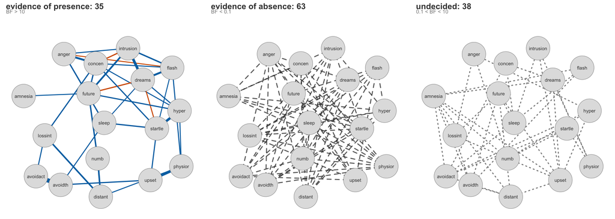

```r
plot(fit)
```

## Exercise: reading the verdicts

**Exercise**

`v` is a data frame with one row per edge; `v$parameter` names the edge and `v$log_bf` holds the evidence.

- ✅ How many edges are undecided? What fraction of all edges is that, with 344 respondents?
- ✅ Which edge has the strongest evidence of absence? What does a supported absence mean for the two symptoms?
- ✅ In the three-symptom model, intrusion–sleep was present in every draw. What is its verdict now?

**Solution**

```r
table(v$verdict)
```

```
 presence undecided   absence
       35        38        63
```

```r
v[which.min(v$log_bf), c("parameter", "pip", "bf", "verdict")]
```

```
          parameter        pip         bf verdict
100 amnesia-startle 0.02348225 0.02404692 absence
```

```r
v[v$parameter == "intrusion-sleep", c("parameter", "pip", "bf", "verdict")]
```

```
         parameter       pip        bf   verdict
12 intrusion-sleep 0.1533666 0.1811488 undecided
```

Over a quarter of the edges are undecided, with a sample most network studies would envy. These are not failures: they mark the pairs for which these data support neither presence nor absence strongly enough. A selection method would have reported each of them as one or the other.

A supported absence is conditional independence: given the other 15 symptoms, the two are unrelated. That is a positive finding about the structure, not a gap in it.

The intrusion–sleep edge that was decisively present with three symptoms is now undecided, with a Bayes factor of 0.18, mild evidence against. With 14 more symptoms in the model, the association between intrusive thoughts and sleep problems is accounted for by other symptoms, and the evidence for a direct edge evaporates. Same lesson as for our relation, in the other direction.

# Checking the Markov Chain

Every number so far is computed from a finite sample of the posterior, so one question comes before any verdict: did the sampler run long enough? The summary prints the answer beside every estimate.

`Rhat` compares the four chains. Each chain started from a different network; if they describe the same posterior, the variance between chains is no larger than the variance within them, and $\hat{R}$ is close to $1$. Values below $1.01$ signal agreement.

`n_eff` is the effective sample size. Consecutive draws of a Markov chain are correlated, so 20,000 draws carry less information than 20,000 independent ones; `n_eff` is the number of independent draws that would carry the same information. A few hundred is enough for stable summaries.

`mcse` is the Monte Carlo standard error, which translates `n_eff` into the scale of the estimate: it is how much the reported mean would move if you reran the sampler. It is the number to compare with the estimate’s own `sd`.

The flip counts `n0->1` and `n1->0` are bookkeeping rather than diagnostics: the number of times each edge switched on and off. An edge with inclusion probability near $0$ or $1$ rarely visits the other state, so small counts are expected there. Precision is read from `n_eff`, not from the flips.

```r
rhat <- extract_rhat(fit)
ess  <- extract_ess(fit)
max(rhat$pairwise); max(rhat$indicator, na.rm = TRUE)
```

```
[1] 1.010551
```

```
[1] 1.012268
```

```r
min(ess$pairwise);  min(ess$indicator, na.rm = TRUE)
```

```
[1] 623.1873
```

```
[1] 394.4663
```

Every effective sample size is in the hundreds or better. The largest $\hat{R}$ is 1.012, on a handful of inclusion indicators, a hair above the $1.01$ rule of thumb: the four chains agree, but a longer run would tighten it, and that is what you would do before publishing. The `NA` values belong to edges that were present in every draw of every chain: there is no variance to compare, and the check for those edges is that four independently started chains all settled on including them.

For our relation, the diagnostics are on the two rows printed above: $\hat{R}$ of 1.001, an effective sample size of 16,171 for the inclusion probability, and a Monte Carlo standard error of 4e-04 on a weight of -0.141. The sampler is not what is driving that number.

Monte Carlo error can change a verdict in only one way: by moving a Bayes factor across a threshold. So it only matters for edges whose evidence already sits near $\pm 2.30$. `verdicts()` flags exactly those. Its `fragile` column marks an edge whose log Bayes factor lies within two Monte Carlo standard errors of a threshold, meaning a rerun could carry it across. A fragile verdict is not a wrong verdict; it is a verdict this run is too short to settle.

```r
v[v$fragile, c("parameter", "pip", "log_bf", "verdict")]
```

```
           parameter        pip    log_bf   verdict
16 intrusion-startle 0.08769467 -2.342114   absence
25       dreams-numb 0.08831020 -2.334444   absence
35    flash-avoidact 0.09785422 -2.221297 undecided
79    avoidth-concen 0.08960248 -2.318498   absence
80     avoidth-hyper 0.08980183 -2.316057   absence
84  avoidact-distant 0.89342747  2.126239 undecided
91  avoidact-startle 0.09890614 -2.209438 undecided
```

When a check fails, or a flagged verdict sits behind a claim you want to make, the remedy is always the same: double the warmup and the iterations and run again.

## Exercise: convergence

**Exercise**

- ✅ Which edge has the smallest effective sample size among the inclusion probabilities? What is its verdict, and why is that not a coincidence?
- ✅ How many verdicts are fragile? Is our relation among them?

**Solution**

```r
worst <- names(which.min(ess$indicator))
worst
```

```
[1] "dreams-upset"
```

```r
v[v$parameter == worst, c("parameter", "pip", "log_bf", "verdict", "fragile")]
```

```
      parameter       pip  log_bf   verdict fragile
18 dreams-upset 0.8596818 1.81265 undecided   FALSE
```

```r
sum(v$fragile)
```

```
[1] 7
```

```r
"intrusion-concen" %in% v$parameter[v$fragile]
```

```
[1] FALSE
```

The smallest effective sample size belongs to an undecided edge. That is as it should be: the sampler keeps switching such an edge on and off because the posterior is genuinely split, and a split posterior is harder to estimate precisely than one that sits at $0$ or $1$.

7 verdicts are fragile, all of them near a threshold. Our relation has a log Bayes factor of 8.1, more than five units above the threshold of $2.30$; no rerun will move it.

# Estimates That Average Over Models

The lecture showed the model-averaged posterior of one edge weight: a point mass at zero, with the probability that the edge is absent, and a density for the weight given that it is present. `plot_edge_posterior()` draws it for any edge. First ours:

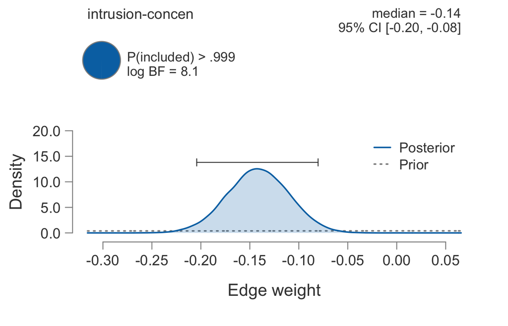

```r
plot_edge_posterior(fit, "intrusion", "concen")
```

The dashed grey curve is the prior on the weight, the slab, the same for every edge. The solid curve is the posterior of the weight given that the edge is present. The wheel is the posterior inclusion probability: its filled share is the probability that the edge is there, its pale share the probability that it is not, and the pale share is the spike at zero that the lecture drew as a stem. The number printed beside it is the natural log of the inclusion Bayes factor.

For our relation the wheel is full and the spike has vanished. Compare an undecided edge and an absent one:

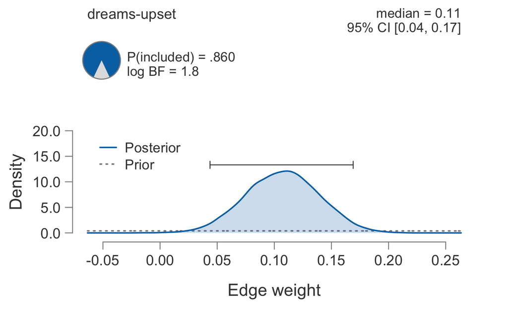

```r
plot_edge_posterior(fit, "dreams", "upset")
```

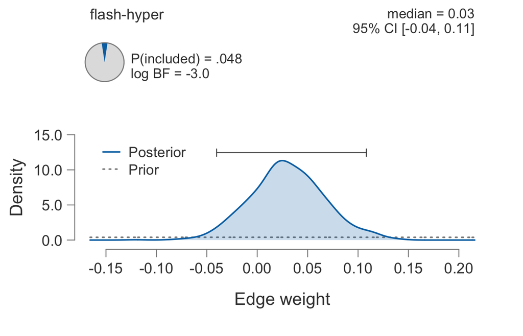

```r
plot_edge_posterior(fit, "flash", "hyper")
```

For dreams–upset the wheel is split, and the model-averaged posterior is the two-part distribution of the lecture: a spike of 0.14 at zero and a slab for the rest. For flash–hyper almost all mass sits in the spike. These three plots are the three verdicts, seen as distributions.

## Exercise: the two-part posterior in numbers

**Exercise**

`extract_pairwise_interactions(fit)` returns the posterior draws of every edge weight, one column per edge. In a draw in which the edge was absent, its weight is exactly zero.

- ✅ For dreams–upset, what fraction of the draws is exactly zero? Where did you see that number before?
- ✅ Compute the 95% credible interval of the model-averaged weight for dreams–upset. Why does it touch zero?
- ✅ Do the same for intrusion–concen.

**Solution**

```r
w <- extract_pairwise_interactions(fit)
mean(w[, "dreams-upset"] == 0)
```

```
[1] 0.1413
```

```r
quantile(w[, "dreams-upset"], c(0.025, 0.975))
```

```
     2.5%     97.5%
0.0000000 0.1667344
```

```r
mean(w[, "intrusion-concen"] == 0)
```

```
[1] 3e-04
```

```r
quantile(w[, "intrusion-concen"], c(0.025, 0.975))
```

```
       2.5%       97.5%
-0.20423184 -0.08015802
```

The fraction of zero draws is the spike: the pale share of the wheel in the plot, and one minus the posterior inclusion probability in the summary. The credible interval of an undecided edge touches zero because the model-averaged posterior has a point mass there; the interval is not saying the weight might be small, it is saying the edge might not be there. For intrusion–concen a handful of the 20,000 draws are zero, the interval sits well away from zero, and model averaging changes next to nothing: once the model uncertainty about an edge is gone, the model-averaged estimate and the estimate given the edge coincide.

The lecture drew all of this as one picture: the prior, the same for every edge, and the three posteriors, one per verdict. The draws are enough to draw it yourself. In each panel the stem is the probability of exactly zero, printed above it, and the curve is the density of the remaining draws scaled to the remaining probability, so stem and curve show how the posterior mass is divided:

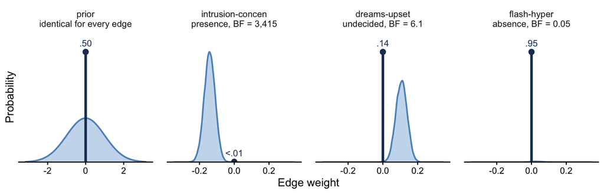

```r
library(ggplot2)
w <- extract_pairwise_interactions(fit)
edges <- c("intrusion-concen", "dreams-upset", "flash-hyper")
fmt_p <- function(p) ifelse(p < 0.01, "<.01", sub("^0", "", sprintf("%.2f", p)))

# the prior: probability .5 of exactly zero, and a standard normal slab for the rest
xp <- seq(-3.2, 3.2, length.out = 512)
curves <- list(data.frame(panel = "prior\nidentical for every edge", x = xp, y = 0.5 * dnorm(xp)))
spikes <- data.frame(panel = "prior\nidentical for every edge", p = 0.5)

# the posteriors: the spike is the share of zero draws, the slab the density of the other draws
for (e in edges) {
  d  <- w[, e]
  p0 <- mean(d == 0)
  ve <- v[v$parameter == e, ]
  title <- sprintf("%s\n%s, BF = %s", e, ve$verdict, if (ve$bf >= 100) fmt(ve$bf, 0) else if (ve$bf >= 1) fmt(ve$bf) else fmt(ve$bf, 2))
  dens <- density(d[d != 0], from = -0.35, to = 0.35, n = 512)
  curves[[e]] <- data.frame(panel = title, x = dens$x, y = dens$y * (1 - p0) * 0.01)
  spikes <- rbind(spikes, data.frame(panel = title, p = p0))
}
curves <- do.call(rbind, curves)
curves$panel <- factor(curves$panel, levels = unique(curves$panel))
spikes$panel <- factor(spikes$panel, levels = levels(curves$panel))

ggplot(curves, aes(x, y)) +
  geom_area(fill = "#C9DCEE", color = "#5B93C4", linewidth = 0.8) +
  geom_segment(data = spikes, aes(x = 0, xend = 0, y = 0, yend = p), color = "#1F3A63", linewidth = 1.3) +
  geom_point(data = spikes, aes(x = 0, y = p), color = "#1F3A63", size = 2.4) +
  geom_text(data = spikes, aes(x = 0, y = p, label = fmt_p(p)), vjust = -0.9, size = 3.4, color = "#1F3A63") +
  scale_y_continuous(expand = expansion(mult = c(0, 0.18))) +
  facet_wrap(~ panel, nrow = 1, scales = "free") +
  labs(x = "Edge weight", y = "Probability") +
  theme_classic(base_size = 12) +
  theme(axis.text.y = element_blank(), axis.ticks.y = element_blank(), axis.line.y = element_blank(),
        strip.background = element_blank(), panel.spacing = unit(1.1, "lines"))
```

This is the figure from the lecture, computed rather than sketched. The wheel and the curve of `plot_edge_posterior()` are the same distribution taken apart, and that is the more useful view for everyday work: the curve tells you what the weight is if the edge is there, the wheel how sure you are that it is. Put together they give the picture above, and it is this picture that a credible interval of the model-averaged weight summarises, spike included.

# Does the Prior Matter?

The inclusion Bayes factor depends on two prior distributions: the prior over structures, and the prior on the weights within a structure. Each check below has the same shape: refit under a different prior, cross the new verdicts against the old, and read the off-diagonal cells. Some verdicts always move. What matters is which ones, in which direction, and whether the claims you want to make are among them.

## The structure prior

The default Bernoulli prior gives every edge inclusion probability $1/2$, independently: 136 separate questions, no correction for asking so many. The Beta-Bernoulli prior treats the density of the network as unknown, gives it a Beta distribution, and lets the data inform it. When most edges turn out to be absent, the prior probability of each remaining edge goes down, which is the Bayesian counterpart of a multiple-comparison correction (Scott & Berger, 2010).

```r
fit_bb <- bgm(wenchuan, edge_prior = beta_bernoulli_prior(alpha = 1, beta = 1),
              iter = 5e3, warmup = 2e3, chains = 4, seed = 1)
```

```r
vbb <- verdicts(fit_bb)
table(bernoulli = v$verdict, beta_bernoulli = vbb$verdict)
```

```
           beta_bernoulli
bernoulli   presence undecided absence
  presence        31         4       0
  undecided        0        28      10
  absence          0         0      63
```

Rows are the verdicts under the default prior, columns the verdicts under the Beta-Bernoulli prior, and the diagonal holds the edges that did not move. 14 of the 136 verdicts change, and all of them change in the same direction: 10 undecided edges become absent and 4 present edges become undecided. No edge gains evidence. That is the correction at work. The data put the density of the network near a third, with a mean inclusion probability of 0.37 under the default prior and 0.34 under the Beta-Bernoulli prior, so each edge now starts from prior odds below one to one, and the inclusion Bayes factor goes down for nearly every edge. The edges that cross a threshold are the ones that were close to it already. Our edge was not:

```r
vbb[vbb$parameter == "intrusion-concen", c("parameter", "pip", "bf", "verdict")]
```

```
          parameter      pip       bf  verdict
14 intrusion-concen 0.985868 69.76114 presence
```

The Bayes factor for intrusion–concen falls from about 3,415 to about 70, a large drop, and the verdict stands with room to spare.

## The prior on the weights

Within a structure, each present edge has a normal prior with scale $1$ on its weight. That is the slab, and it is wide: the estimated weights in this network are around $0.2$. A narrower slab expects smaller weights.

```r
fit_s05 <- bgm(wenchuan, interaction_prior = normal_prior(scale = 0.5),
               iter = 5e3, warmup = 2e3, chains = 4, seed = 1)
```

```r
vs <- verdicts(fit_s05)
table(scale_1 = v$verdict, scale_0.5 = vs$verdict)
```

```
           scale_0.5
scale_1     presence undecided absence
  presence        35         0       0
  undecided        2        36       0
  absence          0        18      45
```

This time the changes run the other way. 20 verdicts move and none toward absence: 18 absent edges become undecided and 2 undecided edges become present, while the 35 presence verdicts are untouched. The reason is what a Bayes factor for absence compares: the prediction of a model in which the weight is exactly zero against the prediction of a model in which the weight is drawn from the slab. A wide slab spends much of its prior mass on weights the data rule out, so its prediction suffers and the spike wins more easily. Narrow the slab and the same comparison becomes fairer to the edge, so absence is harder to establish. Evidence of presence is far less sensitive: once the data pin the weight down, it hardly matters how wide the slab was. Intrusion–concen keeps a Bayes factor of about 1,775.

## The whole range of scales

Two refits give two points. Refitting at every scale you might have chosen is expensive. `prior_sensitivity_check()` refits at a few anchor scales, warm-started from the original fit, fills in the Bayes factor curve between them by reweighting the draws, and classifies each verdict as robust across the range, changed within run-to-run noise, changed beyond it, or too noisy to assess.

```r
psc <- prior_sensitivity_check(fit, seed = 1)
```

```r
psc
```

```
Prior sensitivity check: are the edge verdicts robust to the slab scale?
Bayes-factor curve from 0.4x to 2.5x the chosen scale (anchors at 0.4x, 0.63x,
1x, 1.6x, 2.5x; the 1x anchor is the original fit); 136 edges.

91 of 136 verdicts hold across the whole 0.4x-2.5x range; the exceptions are
named below.

  robust (same verdict at every scale)     90
  changed, within run-to-run noise          3
  changed, beyond run-to-run noise         32
  not certifiable (too noisy to assess)    11

32 edges' verdicts genuinely depend on the scale:
  edge               0.4x       0.63x      1x         1.6x       2.5x
  intrusion-amnesia  undecided  absence    absence    absence    absence
  intrusion-lossint  undecided  absence    absence    absence    absence
  intrusion-numb     undecided  absence    absence    absence    absence
  intrusion-sleep    undecided  undecided  undecided  undecided  absence
  dreams-concen      undecided  undecided  undecided  undecided  absence
  flash-avoidth      undecided  undecided  undecided  absence    absence
  flash-anger        presence   presence   presence   presence   undecided
  flash-hyper        undecided  absence    absence    absence    absence
  flash-startle      presence   presence   presence   undecided  undecided
  upset-distant      undecided  undecided  undecided  undecided  absence
  ...and 22 more; see $edges.

11 edges are too noisy to assess: intrusion-startle, dreams-upset, dreams-numb,
flash-upset, flash-avoidact, upset-avoidact, avoidth-concen, avoidth-hyper,
avoidact-distant, avoidact-startle, and 1 more (see $edges).
Their Bayes factor sits within Monte Carlo error of an evidence threshold, or
their chains disagree on the verdict, at the chosen scale itself; a rerun with
a fresh seed could flip them without any prior change. Run more iterations to
settle these verdicts before reading their sensitivity.

Verdict counts by scale (at the anchors):
            0.4x 0.63x 1x 1.6x 2.5x
  presence    36    36 35   35   31
  undecided   64    50 38   30   29
  absence     36    50 63   71   76
More absence at wider scales is expected: a wider slab strengthens evidence
against borderline edges.

Note: the chosen scale (1) is much wider than the estimated interactions (about
0.18 [0.148, 0.218]); absence verdicts in particular depend on this choice.

Method:  43-point curve from 5 anchor fits (0.4x to 2.5x the chosen scale),
         joined by importance reweighting; the 1x anchor is the original fit.
         Points with reweighting effective sample size below 400 are not shown.
Refits:  5 nuts refits, warm-started from the original fit, 81 s total.
Noise:   two identical refits at 1.6x differed by up to 0.98 log BF across
         threshold-relevant edges; verdict moves smaller than that are reported
         as run-to-run noise, not prior sensitivity.
         4 edges saturated in one of the two and were left out of that spread.
See ?prior_sensitivity_check for the full construction.
```

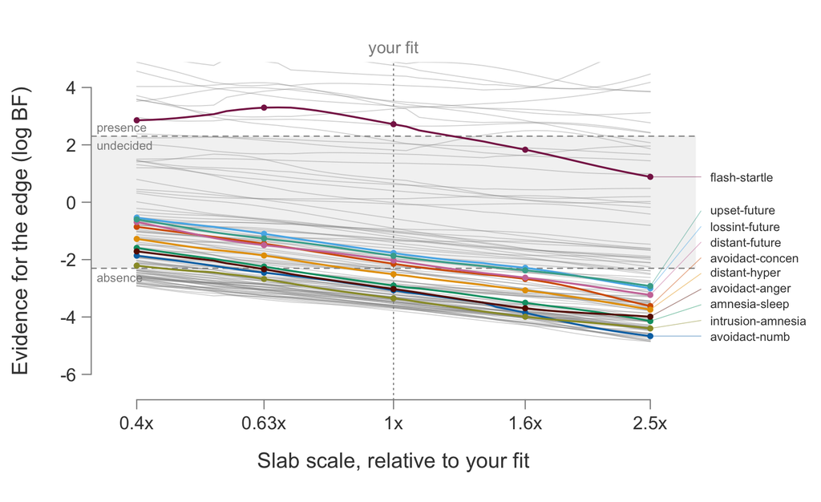

```r
plot(psc)
```

The printed summary sorts the 136 verdicts into four groups, and the plot draws one Bayes factor curve per edge across the range, with the two thresholds as dashed lines and the edges that cross one beyond run-to-run noise named at the right. Nearly every curve slopes down: a wider slab means less evidence for an edge, whatever its verdict. 91 verdicts hold from $0.4$ to $2.5$ times the chosen scale. 32 genuinely depend on it, and they follow the pattern of the cross-tables: at the narrow end absence verdicts become undecided, at the wide end undecided verdicts become absent and a few present edges slip to undecided. The verdict counts at the anchors show the asymmetry. Absence verdicts run from 36 at $0.4\times$ to 76 at $2.5\times$; presence verdicts run from 36 to 31. The remaining 11 edges cannot be assessed, because their Bayes factor sits within Monte Carlo error of a threshold at the chosen scale itself. Dreams–upset, our undecided edge, is one of them. A fresh seed could flip it without any change of prior, and the remedy is a longer run, not a different slab.

The check also names the reason for the asymmetry: the chosen scale of $1$ is wide next to the estimated interactions, and a wide slab favours the spike. It does not tell you which scale is right, and it must not be used to pick one after the fact. It tells you which claims survive the choice.

## Exercise: which verdicts move?

**Exercise**

Use the two cross-tables and the output of the sensitivity check.

- ✅ List the edges that are off the diagonal in each cross-table, with their Bayes factors under the default prior. How far were they from a threshold?
- ✅ Are the edges that move under the Beta-Bernoulli prior the same edges that move under the narrower slab? Why, or why not?
- ✅ Look up intrusion–concen in `psc$edges`. Does its verdict change anywhere in the range? What is the smallest Bayes factor it has had under any of the priors in this section?

**Solution**

```r
v[v$verdict != vbb$verdict, c("parameter", "bf", "verdict")]
```

```
           parameter         bf   verdict
31    dreams-startle 22.0268238  presence
34     flash-avoidth  0.1557847 undecided
35    flash-avoidact  0.1084683 undecided
42       flash-anger 31.8593750  presence
45     flash-startle 14.2921925  presence
52        upset-numb  0.1302282 undecided
53      upset-future  0.1561383 undecided
76    avoidth-future  0.1369348 undecided
89   avoidact-concen  0.1171663 undecided
91  avoidact-startle  0.1097623 undecided
102     lossint-numb  0.1397018 undecided
103   lossint-future  0.1714682 undecided
110   distant-future  0.1331951 undecided
134     concen-hyper 14.6594650  presence
```

```r
v[v$verdict != vs$verdict, c("parameter", "bf", "verdict")]
```

```
            parameter         bf   verdict
10     intrusion-numb 0.06147730   absence
16  intrusion-startle 0.09612425   absence
18       dreams-upset 6.12665911 undecided
25        dreams-numb 0.09686430   absence
32        flash-upset 0.08013750   absence
41        flash-sleep 0.06576952   absence
48     upset-avoidact 0.08880685   absence
55        upset-anger 0.04599012   absence
56       upset-concen 0.08750080   absence
60   physior-avoidact 0.06413910   absence
79     avoidth-concen 0.09842127   absence
80      avoidth-hyper 0.09866185   absence
84   avoidact-distant 8.38328071 undecided
85      avoidact-numb 0.04995715   absence
88     avoidact-anger 0.04940517   absence
96      amnesia-sleep 0.05557257   absence
112     distant-anger 0.06567600   absence
114     distant-hyper 0.07974066   absence
115   distant-startle 0.05637978   absence
119       numb-concen 0.05513894   absence
```

```r
intersect(v$parameter[v$verdict != vbb$verdict], v$parameter[v$verdict != vs$verdict])
```

```
character(0)
```

```r
psc$edges[psc$edges$edge == "intrusion-concen", c("edge", "verdict_x0.4", "verdict_x1", "verdict_x2.5", "mover")]
```

```
               edge verdict_x0.4 verdict_x1 verdict_x2.5  mover
14 intrusion-concen     presence   presence     presence stable
```

```r
min(bf["intrusion", "concen"], vbb$bf[vbb$parameter == "intrusion-concen"], vs$bf[vs$parameter == "intrusion-concen"])
```

```
[1] 69.76114
```

Every edge that moves had a Bayes factor within a factor of about three of a threshold under the default prior: the undecided edges that become absent sat just above $1/10$, the present edges that become undecided sat between $10$ and about $30$, and the absent edges that become undecided sat just below $1/10$. The two sets of movers do not overlap, because the two priors push in opposite directions. The Beta-Bernoulli prior lowers the prior odds and pulls edges just above a threshold down through it; the narrower slab raises the evidence for borderline edges and pushes edges just below the absence threshold up through it. The verdicts that change are the verdicts that were never firm.

Intrusion–concen is stable across the whole range and is not a mover. The smallest Bayes factor it has had in this section is about 70, under the Beta-Bernoulli prior, still far above $10$.

**The conclusion.** Presence verdicts are sturdy. No present edge became absent under any prior in this section, and the few that slipped to undecided did so from just above the threshold, under the multiplicity correction or at the widest slab. Absence verdicts are the fragile ones, in both directions, and the sensitivity check says why: the default slab is wide next to the weights in this network. So report the default analysis, and report the sensitivity check next to it: how many verdicts moved, which way, and whether any claim you make rests on one of them. Choosing the prior after the fact because it gives the cleanest table is not an option.

# Reporting an Analysis With No Selected Model

The reporting question the lecture ended on has a short answer: report the evidence per edge, not a structure. Sekulovski et al. (in preparation) turn that answer into a checklist of what a Methods and a Results section must contain. It was written for the JASP module, but every item is a quantity this tutorial has already computed. The table below is their checklist for an edge-selection analysis, with the JASP column replaced by where the item comes from in `bgms`. Items that only apply to clustering or group comparisons are left out.

| Item | What to report | Where it comes from in `bgms` |
| --- | --- | --- |
| **Methods** |  |  |
| M1 | Software and version | `packageVersion("bgms")` and the R version |
| M2 | Missing-data strategy and the number of cases analysed | The `na_action` argument of `bgm()`, listwise deletion by default; `extract_arguments(fit)$num_cases` |
| M3–M5 | Data, analysis materials, and preregistration, each with a link | Your repository; the script and the saved fit reproduce the analysis |
| M6 | Model type and the measurement level of the variables | The `variable_type` argument; for ordinal variables `bgm()` fits an ordinal Markov random field |
| M7 | Prior on the structure, its hyperparameters, and why if not default | The `edge_prior` argument: `bernoulli_prior()` with inclusion probability $1/2$ by default, `beta_bernoulli_prior()` for the alternative |
| M8 | Prior on the edge weights, its scale, and why if not default | The `interaction_prior` argument: `normal_prior()` with scale $1$ by default, `cauchy_prior()` as alternative |
| M9 | Prior on the main effects | The `threshold_prior` argument: `beta_prime_prior()` with shapes $0.5$ and $0.5$ by default |
| M10 | Prior robustness analysis: which alternatives were fitted | The refits of the previous section, and `prior_sensitivity_check()` |
| M12–M14 | Sampler, number of chains, warmup and post-warmup iterations, seed | The `update_method`, `chains`, `warmup`, `iter`, and `seed` arguments |
| M15 | Convergence criterion and the parameter classes it was checked for | `extract_rhat()` and `extract_ess()` for weights and indicators; $\hat{R} < 1.01$ |
| M16 | Bayes factor cutoff and why if not $10$ | The `evidence_threshold` argument of `verdicts()` |
| M17 | Credible interval type and width | Quantiles of the draws from `extract_pairwise_interactions()` |
| **Results** |  |  |
| R1 | Verdict counts out of the possible edges, and the resulting sparsity | `table(verdicts(fit)$verdict)` |
| R2 | For every edge discussed: inclusion Bayes factor, model-averaged weight, credible interval | `extract_inclusion_bf()`, `summary(fit)$pairwise`, and the draws |
| R3 | Convergence statement: maximum $\hat{R}$ per parameter class, with chains and iterations | `extract_rhat()`; add the fragile flags of `verdicts()` |
| R4 | Robustness summary: which alternatives, and whether any edge changed category | The cross-tables of `verdicts()` and the summary of `prior_sensitivity_check()` |
| R5 | Where the full per-edge table can be found | `verdicts(fit)` and `summary(fit)`, exported to a supplement |
| R6 | A network plot with evidence encoding, or an edge evidence plot | `plot(fit)` |

Two things are on this list that a frequentist network paper never has: the priors, with a reason for any non-default choice, and the robustness analysis. Two things are not on it: a selected structure, and a centrality table for it.

## Two template paragraphs

The checklist becomes two paragraphs. Sekulovski et al. give a template for each; the versions below follow theirs, filled in from this tutorial. They are minimal: a real Results section discusses as many edges as the research question needs, present and absent, and the whole estimated network.

**Methods.**

> We analysed the 17 PTSD symptoms with bgms 0.2.0.0 in R version 4.6.0 (2026-04-24). Because all variables are ordinal, an ordinal Markov random field was fitted. We placed a Bernoulli prior on the network structure with prior inclusion probability $0.5$ for every edge, reflecting no prior expectation about which edges are present, a normal prior centred at zero with scale $1$ on the edge weights, and the default Beta-prime($0.5$, $0.5$) prior on the main effects. Posterior distributions were approximated with the No-U-Turn Sampler using 4 chains of 2,000 warmup and 5,000 post-warmup iterations, with the random seed set to 1. Convergence was assessed with $\hat{R} < 1.01$ for the edge weights and the inclusion indicators, together with effective sample sizes, and verdicts whose log Bayes factor lies within two Monte Carlo standard errors of a threshold were flagged as fragile. Missing observations were handled by listwise deletion, leaving 344 of 362 respondents. We used the inclusion Bayes factor to test, for each edge, the hypothesis that it is present against the hypothesis that it is absent, conditional on the other edges. Edges with a Bayes factor of at least $10$ were classified as present, edges with a Bayes factor of at most $1/10$ as absent, and the rest as undecided. For edges of interest we report the model-averaged edge weight with its 95% credible interval. We checked prior robustness by refitting with a Beta-Bernoulli($1$, $1$) structure prior and with a normal prior of scale $0.5$ on the weights, and by tracing the inclusion Bayes factors across slab scales from $0.4$ to $2.5$ times the chosen scale. The full per-edge results and the robustness analyses are given in [Appendix X]. The analysis script and the saved fits are available at [repository link].

**Results.**

> Of the 136 possible edges, 35 showed evidence of presence (inclusion Bayes factor $\geq 10$), 63 showed evidence of absence ($\leq 1/10$), and 38 were undecided, so the estimated network is sparse, with 26% of the possible edges present. The evidence plots and the estimated network are shown in Figure X; the full per-edge table is given in [Appendix X]. Four chains of 5,000 post-warmup iterations gave a maximum $\hat{R}$ of 1.011 for the edge weights and 1.012 for the inclusion indicators, marginally above the $1.01$ criterion for a few parameters, and an effective sample size of at least 623 for every edge weight. Monte Carlo fragility was flagged for 7 verdicts, none of them behind a claim made here. Intrusive thoughts and concentration problems were negatively associated conditional on the other 15 symptoms (model-averaged weight -0.14, 95% credible interval -0.20 to -0.08, inclusion Bayes factor 3,415). [Interpret other notable findings, both present and absent edges.] Under a Beta-Bernoulli structure prior 14 verdicts changed, all toward less evidence; under a normal prior of scale $0.5$ on the weights 20 changed, all toward more evidence. Across slab scales from $0.4$ to $2.5$ times the chosen scale, 91 of the 136 verdicts held. No edge moved between presence and absence under any setting, and every claim above rests on a verdict that held throughout.

The last two sentences are the ones the previous section earned. Without them, a reader cannot tell a verdict that would survive any reasonable prior from one that was decided by the default.

# From Here

The three verdicts, the inclusion Bayes factor, and the model-averaged weight are not specific to cross-sectional networks. In a temporal network the edges are lagged and directed, $p^2$ of them, and the question per edge is the same: is it there, is it not, or can the data not say. Part III continues with `bvarnet`.

**NoteFurther reading**

- Marsman, M., et al. (in preparation). Bayesian analysis of psychological networks: A tutorial.
- Sekulovski, N., Huth, K., van den Bergh, D., van Doorn, J., Blanken, T. F., Wagenmakers, E.-J., & Marsman, M. (in preparation). Analysis and reporting guidelines for Bayesian graphical modeling of cross-sectional data: A tutorial in JASP.
- Sekulovski, N., Keetelaar, S., Huth, K., Wagenmakers, E.-J., van Bork, R., van den Bergh, D., & Marsman, M. (2024). Testing conditional independence in psychometric networks: An analysis of three Bayesian methods. *Multivariate Behavioral Research*, 59, 913–933.
- Huth, K. B. S., Haslbeck, J. M. B., Keetelaar, S., van Holst, R. J., & Marsman, M. (2025). Statistical evidence in psychological networks: A Bayesian analysis of 294 networks from 126 studies. *Nature Human Behaviour*.
- Hoeting, J. A., Madigan, D., Raftery, A. E., & Volinsky, C. T. (1999). Bayesian model averaging: A tutorial. *Statistical Science*, 14, 382–417.
- Scott, J. G., & Berger, J. O. (2010). Bayes and empirical-Bayes multiplicity adjustment in the variable-selection problem. *The Annals of Statistics*, 38, 2587–2619.